# STAT412 HOMEWORK1

Sidar Yük-2291052

2024-03-17

# ABSTRACT

```r
library(zoo)
library(readxl)
library(stringr)
library(dplyr)
library(RColorBrewer)
library(ggplot2)
library(corrplot)
```

# Data Cleaning

**Part1 and Part2**

```r
amazon <- read_xlsx("Amazon.xlsx")
head(amazon)
```

```
## # A tibble: 6 × 14
##   Amazon Sales Dataset :…¹ ...2  ...3  ...4  ...5  ...6  ...7  ...8  ...9  ...10
##   <chr>                    <chr> <chr> <chr> <chr> <chr> <chr> <chr> <chr> <chr>
## 1 <NA>                     <NA>  <NA>  <NA>  <NA>  <NA>  <NA>  <NA>  <NA>  <NA>
## 2 CATEGORY                 PROD… YEASR QUAR… Quar… Cust… SELL… the … the … Unit…
## 3 Electronics              E1    2018  Q1    1200  4     4     200   10    50
## 4 Clothing                 C2    2019  Q2    800   5     4     50    5     200
## 5 Books                    B3    2020  Q3    600   4     3     30    15    100
## 6 Home & Kitchen           H4    2021  Q4    1500  5     5     120   8     30
## # ℹ abbreviated name:
## #   ¹`Amazon Sales Dataset : The dataset consists of 121 observations`
## # ℹ 4 more variables: ...11 <chr>, ...12 <chr>, ...13 <chr>, ...14 <chr>
```

The first problem arises in the first two rows. I prefer to skip these rows

```r
amazon1 <- read_xlsx("Amazon.xlsx", skip = 2, na = "NA")
```

```r
head(amazon1)
```

```
## # A tibble: 6 × 14
##   CATEGORY    PRODUCTID YEASR QUARTER QuarterlySales CustomerRating SELLERRATING
##   <chr>       <chr>     <dbl> <chr>            <dbl>          <dbl>        <dbl>
## 1 Electronics E1         2018 Q1                1200              4            4
## 2 Clothing    C2         2019 Q2                 800              5            4
## 3 Books       B3         2020 Q3                 600              4            3
## 4 Home & Kit… H4         2021 Q4                1500              5            5
## 5 Beauty      B5         2018 Q1                1000              4            3
## 6 Electronics E6         2022 Q2                 900              4            4
## # ℹ 7 more variables: `the product price in USD.` <dbl>,
## #   `the discount applied to the product in percentage` <dbl>, UnitsSold <dbl>,
## #   Revenue <dbl>, ShippingMethod <chr>, `the location of the sale` <chr>,
## #   AdvertisingCost <dbl>
```

```r
tail(amazon1)
```

```
## # A tibble: 6 × 14
##   CATEGORY    PRODUCTID YEASR QUARTER QuarterlySales CustomerRating SELLERRATING
##   <chr>       <chr>     <dbl> <chr>            <dbl>          <dbl>        <dbl>
## 1 Beauty      B25        2018 Q2                1050              4            3
## 2 Electronics E26        2019 Q3                 950              5            4
## 3 Clothing    C27        2020 Q4                 680              4            3
## 4 Books       B28        2021 Q1                 880              5            5
## 5 Home & Kit… H29        2018 Q2                1300              4            3
## 6 Beauty      B30        2019 Q3                1100              5            5
## # ℹ 7 more variables: `the product price in USD.` <dbl>,
## #   `the discount applied to the product in percentage` <dbl>, UnitsSold <dbl>,
## #   Revenue <dbl>, ShippingMethod <chr>, `the location of the sale` <chr>,
## #   AdvertisingCost <dbl>
```

data is imported correctly

```r
class(amazon1)
```

```
## [1] "tbl_df"     "tbl"        "data.frame"
```

data frames as the starting point for analysis dataset needs to be converted to data frame

```r
amazon1 = as.data.frame(amazon1)
class(amazon1)
```

```
## [1] "data.frame"
```

dataset converted to dataframe

```r
sum(is.na(amazon1))
```

```
## [1] 6
```

the dataset has 6 NA values

```r
amazon1 <- na.omit(amazon1)
sum(is.na(amazon1))
```

```
## [1] 0
```

remove rows containing NA values.Now, the dataset does not have NA values  
**Part3**

```r
head(amazon1)
```

```
##         CATEGORY PRODUCTID YEASR QUARTER QuarterlySales CustomerRating
## 1    Electronics        E1  2018      Q1           1200              4
## 2       Clothing        C2  2019      Q2            800              5
## 3          Books        B3  2020      Q3            600              4
## 4 Home & Kitchen        H4  2021      Q4           1500              5
## 5         Beauty        B5  2018      Q1           1000              4
## 6    Electronics        E6  2022      Q2            900              4
##   SELLERRATING the product price in USD.
## 1            4                       200
## 2            4                        50
## 3            3                        30
## 4            5                       120
## 5            3                        80
## 6            4                       250
##   the discount applied to the product in percentage UnitsSold Revenue
## 1                                                10        50   10000
## 2                                                 5       200   16000
## 3                                                15       100    6000
## 4                                                 8        30   45000
## 5                                                12        40   40000
## 6                                                 8        30   27000
##   ShippingMethod the location of the sale AdvertisingCost
## 1       Standard                       US             500
## 2        Express                       EU             200
## 3       Standard                     Asia             300
## 4        Express                       US             700
## 5       Standard                       EU             400
## 6       Standard                     Asia             600
```

```r
tail(amazon1)
```

```
##           CATEGORY PRODUCTID YEASR QUARTER QuarterlySales CustomerRating
## 117         Beauty       B25  2018      Q2           1050              4
## 118    Electronics       E26  2019      Q3            950              5
## 119       Clothing       C27  2020      Q4            680              4
## 120          Books       B28  2021      Q1            880              5
## 121 Home & Kitchen       H29  2018      Q2           1300              4
## 122         Beauty       B30  2019      Q3           1100              5
##     SELLERRATING the product price in USD.
## 117            3                        75
## 118            4                       230
## 119            3                        55
## 120            5                        38
## 121            3                        90
## 122            5                        80
##     the discount applied to the product in percentage UnitsSold Revenue
## 117                                                12        30   31500
## 118                                                18        25   23750
## 119                                                 8        70    4760
## 120                                                12        60    5280
## 121                                                15        25   32500
## 122                                                10        40   44000
##     ShippingMethod the location of the sale AdvertisingCost
## 117       Standard                       US             350
## 118        Express                       EU             500
## 119       Standard                     Asia             150
## 120        Express                       US             200
## 121       Standard                       EU             600
## 122        Express                     Asia             400
```

no tidying required  
**Part4**

```r
colnames(amazon1)
```

```
##  [1] "CATEGORY"
##  [2] "PRODUCTID"
##  [3] "YEASR"
##  [4] "QUARTER"
##  [5] "QuarterlySales"
##  [6] "CustomerRating"
##  [7] "SELLERRATING"
##  [8] "the product price in USD."
##  [9] "the discount applied to the product in percentage"
## [10] "UnitsSold"
## [11] "Revenue"
## [12] "ShippingMethod"
## [13] "the location of the sale"
## [14] "AdvertisingCost"
```

there seems to be a problem with the column names

```r
colnames(amazon1) = str_to_title(colnames(amazon1))
colnames(amazon1)
```

```
##  [1] "Category"
##  [2] "Productid"
##  [3] "Yeasr"
##  [4] "Quarter"
##  [5] "Quarterlysales"
##  [6] "Customerrating"
##  [7] "Sellerrating"
##  [8] "The Product Price In Usd."
##  [9] "The Discount Applied To The Product In Percentage"
## [10] "Unitssold"
## [11] "Revenue"
## [12] "Shippingmethod"
## [13] "The Location Of The Sale"
## [14] "Advertisingcost"
```

column names renamed as headers after deleting the unnecessary dot in the column title

```r
new_title=colnames(amazon1)
new_title2=str_remove_all(new_title,"\\.")
new_title2
```

```
##  [1] "Category"
##  [2] "Productid"
##  [3] "Yeasr"
##  [4] "Quarter"
##  [5] "Quarterlysales"
##  [6] "Customerrating"
##  [7] "Sellerrating"
##  [8] "The Product Price In Usd"
##  [9] "The Discount Applied To The Product In Percentage"
## [10] "Unitssold"
## [11] "Revenue"
## [12] "Shippingmethod"
## [13] "The Location Of The Sale"
## [14] "Advertisingcost"
```

the third variable we have to obtain is Year instead of Yeasr, and the eighth, ninth, and thirteenth variables seem to be problematic

```r
new_title2[c(3)]=str_replace(new_title2[3],"s","r")
new_title2
```

```
##  [1] "Category"
##  [2] "Productid"
##  [3] "Yearr"
##  [4] "Quarter"
##  [5] "Quarterlysales"
##  [6] "Customerrating"
##  [7] "Sellerrating"
##  [8] "The Product Price In Usd"
##  [9] "The Discount Applied To The Product In Percentage"
## [10] "Unitssold"
## [11] "Revenue"
## [12] "Shippingmethod"
## [13] "The Location Of The Sale"
## [14] "Advertisingcost"
```

```r
new_title2[c(3)]=str_sub(new_title2[3],1,4)
new_title2
```

```
##  [1] "Category"
##  [2] "Productid"
##  [3] "Year"
##  [4] "Quarter"
##  [5] "Quarterlysales"
##  [6] "Customerrating"
##  [7] "Sellerrating"
##  [8] "The Product Price In Usd"
##  [9] "The Discount Applied To The Product In Percentage"
## [10] "Unitssold"
## [11] "Revenue"
## [12] "Shippingmethod"
## [13] "The Location Of The Sale"
## [14] "Advertisingcost"
```

the column name of the third problem has been solved

```r
new_title2[c(8,9,13)]=c("Price","Discount","Location")
new_title2
```

```
##  [1] "Category"        "Productid"       "Year"            "Quarter"
##  [5] "Quarterlysales"  "Customerrating"  "Sellerrating"    "Price"
##  [9] "Discount"        "Unitssold"       "Revenue"         "Shippingmethod"
## [13] "Location"        "Advertisingcost"
```

```r
colnames(amazon1)=new_title2
head(amazon1)
```

```
##         Category Productid Year Quarter Quarterlysales Customerrating
## 1    Electronics        E1 2018      Q1           1200              4
## 2       Clothing        C2 2019      Q2            800              5
## 3          Books        B3 2020      Q3            600              4
## 4 Home & Kitchen        H4 2021      Q4           1500              5
## 5         Beauty        B5 2018      Q1           1000              4
## 6    Electronics        E6 2022      Q2            900              4
##   Sellerrating Price Discount Unitssold Revenue Shippingmethod Location
## 1            4   200       10        50   10000       Standard       US
## 2            4    50        5       200   16000        Express       EU
## 3            3    30       15       100    6000       Standard     Asia
## 4            5   120        8        30   45000        Express       US
## 5            3    80       12        40   40000       Standard       EU
## 6            4   250        8        30   27000       Standard     Asia
##   Advertisingcost
## 1             500
## 2             200
## 3             300
## 4             700
## 5             400
## 6             600
```

the column names of the eight,ninth, and thirteen problem have been solved There is no problem anymore in colnames  
**Part5**

```r
amazon1 <- select(amazon1,-Productid)
head(amazon1)
```

```
##         Category Year Quarter Quarterlysales Customerrating Sellerrating Price
## 1    Electronics 2018      Q1           1200              4            4   200
## 2       Clothing 2019      Q2            800              5            4    50
## 3          Books 2020      Q3            600              4            3    30
## 4 Home & Kitchen 2021      Q4           1500              5            5   120
## 5         Beauty 2018      Q1           1000              4            3    80
## 6    Electronics 2022      Q2            900              4            4   250
##   Discount Unitssold Revenue Shippingmethod Location Advertisingcost
## 1       10        50   10000       Standard       US             500
## 2        5       200   16000        Express       EU             200
## 3       15       100    6000       Standard     Asia             300
## 4        8        30   45000        Express       US             700
## 5       12        40   40000       Standard       EU             400
## 6        8        30   27000       Standard     Asia             600
```

Productid was deleted as unnecessary  
**Part6**

```r
dim(amazon1)
```

```
## [1] 116  13
```

dimension of dataset

```r
sum(duplicated(amazon1))
```

```
## [1] 3
```

There are three duplicates

```r
amazon1 <- unique(amazon1)
```

Rows containing duplicates were deleted

```r
dim(amazon1)
```

```
## [1] 113  13
```

new dimension now has 113 rows  
**Part7, Part8, Part9, Part10**

All variables were examined one by one in these parts.

**Checking Category**

```r
table(amazon1$Category)
```

```
##
##         Beauty         BEAUTY           Book          Books       Clothing
##             20              1              3             20             23
##    Electronics    ELECTRONICS Home - Kitchen Home & Kitchen
##             21              1              2             22
```

There are problems such as entering too many letters, signs with the same meaning, and uppercase and lowercase letters.

```r
amazon1[amazon1$Category == "BEAUTY", "Category"] <- "Beauty"
amazon1[amazon1$Category == "Book", "Category"] <- "Books"
amazon1[amazon1$Category == "ELECTRONICS", "Category"] <- "Electronics"
amazon1[amazon1$Category == "Home - Kitchen", "Category"] <- "Home & Kitchen"
table(amazon1$Category)
```

```
##
##         Beauty          Books       Clothing    Electronics Home & Kitchen
##             21             23             23             22             24
```

the problem of category has been solved

**Checking Quarter**

```r
table(amazon1$Quarter)
```

```
##
## Q1 Q2 Q3 Q4
## 27 30 28 28
```

there are no problem

**Checking Year**

```r
table(amazon1$Year)
```

```
##
##  2018  2019  2020  2021  2022 20199 20211
##    27    27    29    27     1     1     1
```

When entering dates, the last digit is overprinted in some.

```r
amazon1[amazon1$Year == 20199,]$Year=2019
amazon1[amazon1$Year == 20211,]$Year=2021
table(amazon1$Year)
```

```
##
## 2018 2019 2020 2021 2022
##   27   28   29   28    1
```

the problem of year has been solved

**Checking Quarterly Sales**

```r
table(amazon1$Quarterlysales)
```

```
##
##  580  600  680  700  750  800  820  850  880  900  950  980 1000 1050 1100 1200
##    1    4    1    4    9   10    2    5    2    4   14    1    4    6   15   10
## 1250 1300 1400 1500 1600
##    1    7   10    2    1
```

there are no problem

**Checking Customer rating**

```r
table(amazon1$Customerrating)
```

```
##
## -5 -4  3  4  5
##  1  1  3 55 53
```

There is no negative value in customer rating

```r
amazon1$Customerrating[amazon1$Customerrating == -5] = 5
amazon1$Customerrating[amazon1$Customerrating == -4] = 4
table(amazon1$Customerrating)
```

```
##
##  3  4  5
##  3 56 54
```

**Checking Seller rating**

```r
table(amazon1$Sellerrating)
```

```
##
##  3  4  5
## 39 40 34
```

there are no problem

**Checking Price**

```r
table(amazon1$Price)
```

```
##
##  30  33  35  38  40  45  50  55  60  70  75  80  90 100 110 120 130 180 200 220
##   9   1   9   1   3   1   9   5   9   4   2   7   8   5   8   9   1   1  10   4
## 230 250
##   1   6
```

there are no problem

**Checking Discount**

```r
table(amazon1$Discount)
```

```
##
## 0.08  0.2    5    8   10   12   15   18   20
##    1    1    9   20   19   20   19   14   10
```

Because of the % sign in the data, 8 looks like 0.08, and 20 looks like 0.2.

```r
amazon1[amazon1$Discount == 0.08,]$Discount = 8
amazon1[amazon1$Discount == 0.2,]$Discount = 20
table(amazon1$Discount)
```

```
##
##  5  8 10 12 15 18 20
##  9 21 19 20 19 14 11
```

the problems of the Discount has been solved

**Checking Units sold**

```r
table(amazon1$Unitssold)
```

```
##
##  20  25  30  35  40  45  50  60  70  80  90 100 120 150 180 200
##  11  13  14   4  10   2  10  11   1   6   1  10   4   7   5   4
```

there are no problem

**Checking Revenue**

```r
table(amazon1$Revenue)
```

```
##
##  4760  5220  5280  5700  6000  7200  8400  8800  9000  9600 10000 10500 10800
##     1     1     1     1     2     1     1     2     3     2     1     3     4
## 11250 12750 14760 15000 16000 22000 22500 23750 24000 26000 26400 27000 28000
##     1     3     1     5     8     2     1     6     2     4     1     1     2
## 28500 30000 31500 32000 32500 32800 35000 36000 40000 42500 42750 44000 45000
##     2     4     1     1     3     1     1     4     1     3     1     5     2
## 47500 48000 49000 55000 56250 63000 78000 84000
##     3     1     5     5     1     6     1     2
```

there are no problem

**Checking Shipping method**

```r
table(amazon1$Shippingmethod)
```

```
##
##  Express Standard
##       56       57
```

there are no problem

**Checking Location**

```r
table(amazon1$Location)
```

```
##
##           Asia           ASIA             EU European Union  United States
##             37              2             35              2              2
##             US
##             35
```

uppercase and lowercase letter problem and location and abbreviation written separately

```r
amazon1[amazon1$Location == "ASIA", "Location"] <- "Asia"
amazon1[amazon1$Location == "European Union", "Location"] <- "EU"
amazon1[amazon1$Location == "United States", "Location"] <- "US"
table(amazon1$Location)
```

```
##
## Asia   EU   US
##   39   37   37
```

the problem of the location has been solved

**Checking Advertising Cost**

```r
table(amazon1$Advertisingcost)
```

```
##
## 150 180 200 250 300 350 400 450 500 600 700 800 900
##   2   1  11  14  20   2  12  11  10   9  14   6   1
```

there are no problem  
**Part11, Part12, Part13**

```r
str(amazon1)
```

```
## 'data.frame':    113 obs. of  13 variables:
##  $ Category       : chr  "Electronics" "Clothing" "Books" "Home & Kitchen" ...
##  $ Year           : num  2018 2019 2020 2021 2018 ...
##  $ Quarter        : chr  "Q1" "Q2" "Q3" "Q4" ...
##  $ Quarterlysales : num  1200 800 600 1500 1000 900 700 1200 1300 1100 ...
##  $ Customerrating : num  4 5 4 5 4 4 5 4 5 4 ...
##  $ Sellerrating   : num  4 4 3 5 3 4 5 3 4 5 ...
##  $ Price          : num  200 50 30 120 80 250 60 35 110 90 ...
##  $ Discount       : num  10 5 15 8 12 8 10 20 15 18 ...
##  $ Unitssold      : num  50 200 100 30 40 30 150 80 20 50 ...
##  $ Revenue        : num  10000 16000 6000 45000 40000 27000 10500 9600 26000 55000 ...
##  $ Shippingmethod : chr  "Standard" "Express" "Standard" "Express" ...
##  $ Location       : chr  "US" "EU" "Asia" "US" ...
##  $ Advertisingcost: num  500 200 300 700 400 600 300 250 800 450 ...
##  - attr(*, "na.action")= 'omit' Named int [1:6] 16 32 38 39 51 97
##   ..- attr(*, "names")= chr [1:6] "16" "32" "38" "39" ...
```

```r
amazon1$Category=as.factor(amazon1$Category)
amazon1$Year <- as.factor(amazon1$Year)
amazon1$Quarter=as.factor(amazon1$Quarter)
amazon1$Quarterlysales=as.integer(amazon1$Quarterlysales)
amazon1$Customerrating=as.factor(amazon1$Customerrating)
amazon1$Sellerrating=as.factor(amazon1$Sellerrating)
amazon1$Price=as.integer(amazon1$Price)
amazon1$Discount=as.integer(amazon1$Discount)
amazon1$Unitssold=as.integer(amazon1$Unitssold)
amazon1$Revenue=as.integer(amazon1$Revenue)
amazon1$Shippingmethod=as.factor(amazon1$Shippingmethod)
amazon1$Location=as.factor(amazon1$Location)
amazon1$Advertisingcost=as.numeric(amazon1$Advertisingcost)
```

```r
table(amazon1$Customerrating)
```

```
##
##  3  4  5
##  3 56 54
```

Customer rating have three level

```r
table(amazon1$Sellerrating)
```

```
##
##  3  4  5
## 39 40 34
```

Seller rating have three level

```r
levels(amazon1$Customerrating) <- c("bad", "medium", "good")
levels(amazon1$Sellerrating) <- c("bad", "medium", "good")
str(amazon1)
```

```
## 'data.frame':    113 obs. of  13 variables:
##  $ Category       : Factor w/ 5 levels "Beauty","Books",..: 4 3 2 5 1 4 3 2 5 1 ...
##  $ Year           : Factor w/ 5 levels "2018","2019",..: 1 2 3 4 1 5 2 3 4 1 ...
##  $ Quarter        : Factor w/ 4 levels "Q1","Q2","Q3",..: 1 2 3 4 1 2 3 4 1 2 ...
##  $ Quarterlysales : int  1200 800 600 1500 1000 900 700 1200 1300 1100 ...
##  $ Customerrating : Factor w/ 3 levels "bad","medium",..: 2 3 2 3 2 2 3 2 3 2 ...
##  $ Sellerrating   : Factor w/ 3 levels "bad","medium",..: 2 2 1 3 1 2 3 1 2 3 ...
##  $ Price          : int  200 50 30 120 80 250 60 35 110 90 ...
##  $ Discount       : int  10 5 15 8 12 8 10 20 15 18 ...
##  $ Unitssold      : int  50 200 100 30 40 30 150 80 20 50 ...
##  $ Revenue        : int  10000 16000 6000 45000 40000 27000 10500 9600 26000 55000 ...
##  $ Shippingmethod : Factor w/ 2 levels "Express","Standard": 2 1 2 1 2 2 1 2 1 2 ...
##  $ Location       : Factor w/ 3 levels "Asia","EU","US": 3 2 1 3 2 1 3 2 1 3 ...
##  $ Advertisingcost: num  500 200 300 700 400 600 300 250 800 450 ...
##  - attr(*, "na.action")= 'omit' Named int [1:6] 16 32 38 39 51 97
##   ..- attr(*, "names")= chr [1:6] "16" "32" "38" "39" ...
```

```r
summary(amazon1)
```

```
##            Category    Year    Quarter Quarterlysales Customerrating
##  Beauty        :21   2018:27   Q1:27   Min.   : 580   bad   : 3
##  Books         :23   2019:28   Q2:30   1st Qu.: 800   medium:56
##  Clothing      :23   2020:29   Q3:28   Median : 980   good  :54
##  Electronics   :22   2021:28   Q4:28   Mean   :1013
##  Home & Kitchen:24   2022: 1           3rd Qu.:1200
##                                        Max.   :1600
##  Sellerrating     Price          Discount       Unitssold         Revenue
##  bad   :39    Min.   : 30.0   Min.   : 5.00   Min.   : 20.00   Min.   : 4760
##  medium:40    1st Qu.: 50.0   1st Qu.: 8.00   1st Qu.: 30.00   1st Qu.:15000
##  good  :34    Median : 80.0   Median :12.00   Median : 50.00   Median :26400
##               Mean   : 98.9   Mean   :12.39   Mean   : 67.48   Mean   :30049
##               3rd Qu.:120.0   3rd Qu.:15.00   3rd Qu.:100.00   3rd Qu.:44000
##               Max.   :250.0   Max.   :20.00   Max.   :200.00   Max.   :84000
##   Shippingmethod Location  Advertisingcost
##  Express :56     Asia:39   Min.   :150.0
##  Standard:57     EU  :37   1st Qu.:300.0
##                  US  :37   Median :400.0
##                            Mean   :429.5
##                            3rd Qu.:600.0
##                            Max.   :900.0
```

Customer rating and seller rating values have been changed to 3 for bad, 4 for medium and 5 for good.  
**Part14**

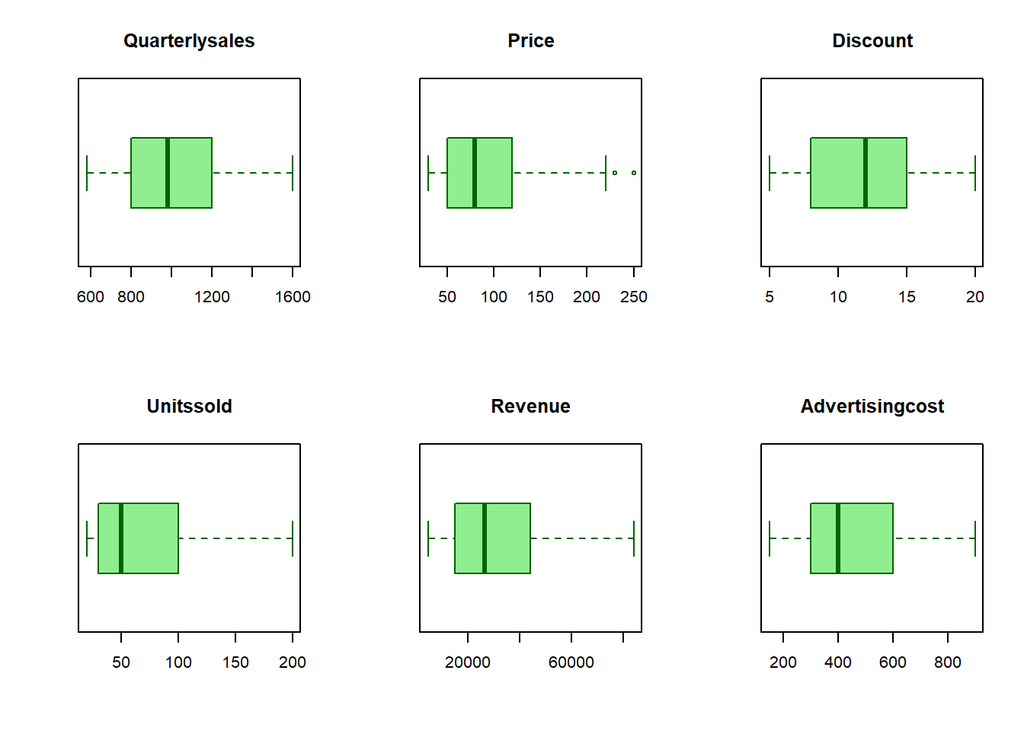

```r
boxplot_data <- amazon1 %>%
  select(Quarterlysales, Price, Discount, Unitssold, Revenue, Advertisingcost)

par(mfrow=c(2, 3))
for (col in colnames(boxplot_data)) {
  boxplot(boxplot_data[[col]], main = col, col = "lightgreen", border = "darkgreen", horizontal = TRUE)
}
```

price has two outliers, so ı apply the Tukey method

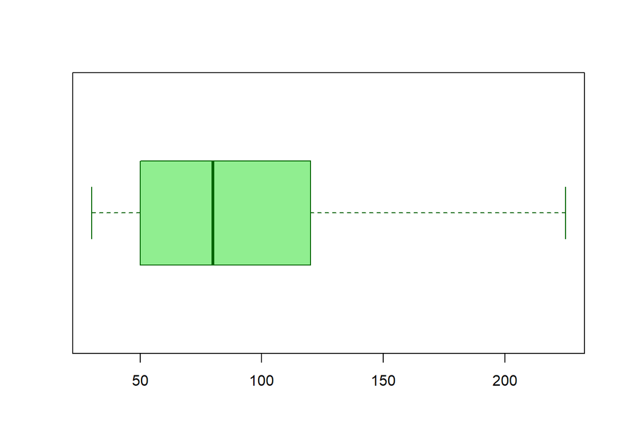

```r
Q1 <- quantile(amazon1$Price, 0.25)
Q3 <- quantile(amazon1$Price, 0.75)
IQR <- Q3 - Q1
lower_bound <- Q1 - 1.5 * IQR
upper_bound <- Q3 + 1.5 * IQR

amazon1$Price[amazon1$Price < lower_bound] <- lower_bound
amazon1$Price[amazon1$Price > upper_bound] <- upper_bound

par(mfrow=c(1, 1))
boxplot(amazon1$Price, col = "lightgreen", border = "darkgreen", horizontal = TRUE)
```

Outlier problem solved according to box plot

**Part15, Part16**

```r
str(amazon1)
```

```
## 'data.frame':    113 obs. of  13 variables:
##  $ Category       : Factor w/ 5 levels "Beauty","Books",..: 4 3 2 5 1 4 3 2 5 1 ...
##  $ Year           : Factor w/ 5 levels "2018","2019",..: 1 2 3 4 1 5 2 3 4 1 ...
##  $ Quarter        : Factor w/ 4 levels "Q1","Q2","Q3",..: 1 2 3 4 1 2 3 4 1 2 ...
##  $ Quarterlysales : int  1200 800 600 1500 1000 900 700 1200 1300 1100 ...
##  $ Customerrating : Factor w/ 3 levels "bad","medium",..: 2 3 2 3 2 2 3 2 3 2 ...
##  $ Sellerrating   : Factor w/ 3 levels "bad","medium",..: 2 2 1 3 1 2 3 1 2 3 ...
##  $ Price          : num  200 50 30 120 80 225 60 35 110 90 ...
##  $ Discount       : int  10 5 15 8 12 8 10 20 15 18 ...
##  $ Unitssold      : int  50 200 100 30 40 30 150 80 20 50 ...
##  $ Revenue        : int  10000 16000 6000 45000 40000 27000 10500 9600 26000 55000 ...
##  $ Shippingmethod : Factor w/ 2 levels "Express","Standard": 2 1 2 1 2 2 1 2 1 2 ...
##  $ Location       : Factor w/ 3 levels "Asia","EU","US": 3 2 1 3 2 1 3 2 1 3 ...
##  $ Advertisingcost: num  500 200 300 700 400 600 300 250 800 450 ...
##  - attr(*, "na.action")= 'omit' Named int [1:6] 16 32 38 39 51 97
##   ..- attr(*, "names")= chr [1:6] "16" "32" "38" "39" ...
```

The units in the numeric columns are in the same format

```r
sum(is.na(amazon1))
```

```
## [1] 0
```

there are no missing values

Data cleaning is completed now we can start “eda”

# EDA

```r
str(amazon1)
```

```
## 'data.frame':    113 obs. of  13 variables:
##  $ Category       : Factor w/ 5 levels "Beauty","Books",..: 4 3 2 5 1 4 3 2 5 1 ...
##  $ Year           : Factor w/ 5 levels "2018","2019",..: 1 2 3 4 1 5 2 3 4 1 ...
##  $ Quarter        : Factor w/ 4 levels "Q1","Q2","Q3",..: 1 2 3 4 1 2 3 4 1 2 ...
##  $ Quarterlysales : int  1200 800 600 1500 1000 900 700 1200 1300 1100 ...
##  $ Customerrating : Factor w/ 3 levels "bad","medium",..: 2 3 2 3 2 2 3 2 3 2 ...
##  $ Sellerrating   : Factor w/ 3 levels "bad","medium",..: 2 2 1 3 1 2 3 1 2 3 ...
##  $ Price          : num  200 50 30 120 80 225 60 35 110 90 ...
##  $ Discount       : int  10 5 15 8 12 8 10 20 15 18 ...
##  $ Unitssold      : int  50 200 100 30 40 30 150 80 20 50 ...
##  $ Revenue        : int  10000 16000 6000 45000 40000 27000 10500 9600 26000 55000 ...
##  $ Shippingmethod : Factor w/ 2 levels "Express","Standard": 2 1 2 1 2 2 1 2 1 2 ...
##  $ Location       : Factor w/ 3 levels "Asia","EU","US": 3 2 1 3 2 1 3 2 1 3 ...
##  $ Advertisingcost: num  500 200 300 700 400 600 300 250 800 450 ...
##  - attr(*, "na.action")= 'omit' Named int [1:6] 16 32 38 39 51 97
##   ..- attr(*, "names")= chr [1:6] "16" "32" "38" "39" ...
```

```r
summary(amazon1)
```

```
##            Category    Year    Quarter Quarterlysales Customerrating
##  Beauty        :21   2018:27   Q1:27   Min.   : 580   bad   : 3
##  Books         :23   2019:28   Q2:30   1st Qu.: 800   medium:56
##  Clothing      :23   2020:29   Q3:28   Median : 980   good  :54
##  Electronics   :22   2021:28   Q4:28   Mean   :1013
##  Home & Kitchen:24   2022: 1           3rd Qu.:1200
##                                        Max.   :1600
##  Sellerrating     Price           Discount       Unitssold         Revenue
##  bad   :39    Min.   : 30.00   Min.   : 5.00   Min.   : 20.00   Min.   : 4760
##  medium:40    1st Qu.: 50.00   1st Qu.: 8.00   1st Qu.: 30.00   1st Qu.:15000
##  good  :34    Median : 80.00   Median :12.00   Median : 50.00   Median :26400
##               Mean   : 97.53   Mean   :12.39   Mean   : 67.48   Mean   :30049
##               3rd Qu.:120.00   3rd Qu.:15.00   3rd Qu.:100.00   3rd Qu.:44000
##               Max.   :225.00   Max.   :20.00   Max.   :200.00   Max.   :84000
##   Shippingmethod Location  Advertisingcost
##  Express :56     Asia:39   Min.   :150.0
##  Standard:57     EU  :37   1st Qu.:300.0
##                  US  :37   Median :400.0
##                            Mean   :429.5
##                            3rd Qu.:600.0
##                            Max.   :900.0
```

Category:a factor with levels: Beauty, Books, Clothing, Electronics, Home & Kitchen  
Year: a factor with levels: 2018,2019,2020,2021,2021  
Quarter: a factor with levels: Q1,Q2,Q3,Q4 which represent the quarter of the year  
Quarterlysales: a integer vector  
Customerrating: a factor with levels:bad,medium,good  
Sellerrating: a factor with levels:bad,medium,good  
Price: a numeric vector  
Discount: a integer vector which representing the discount applied to the product in percentage  
Unitssold: a integer vector  
Revenue: a integer vector  
Shippingmethod: a factor with levels: Express and Standard  
Location: a factor with levels: Asia, EU, US  
Advertisingcost: a numeric vector  
**Question1**

How do the frequencies of shipping methods differ across various locations?

```r
par(mfrow=c(1, 1))
ship_loc = table(amazon1$Shippingmethod,amazon1$Location)
ship_loc
```

```
##
##            Asia EU US
##   Express    18 20 18
##   Standard   21 17 19
```

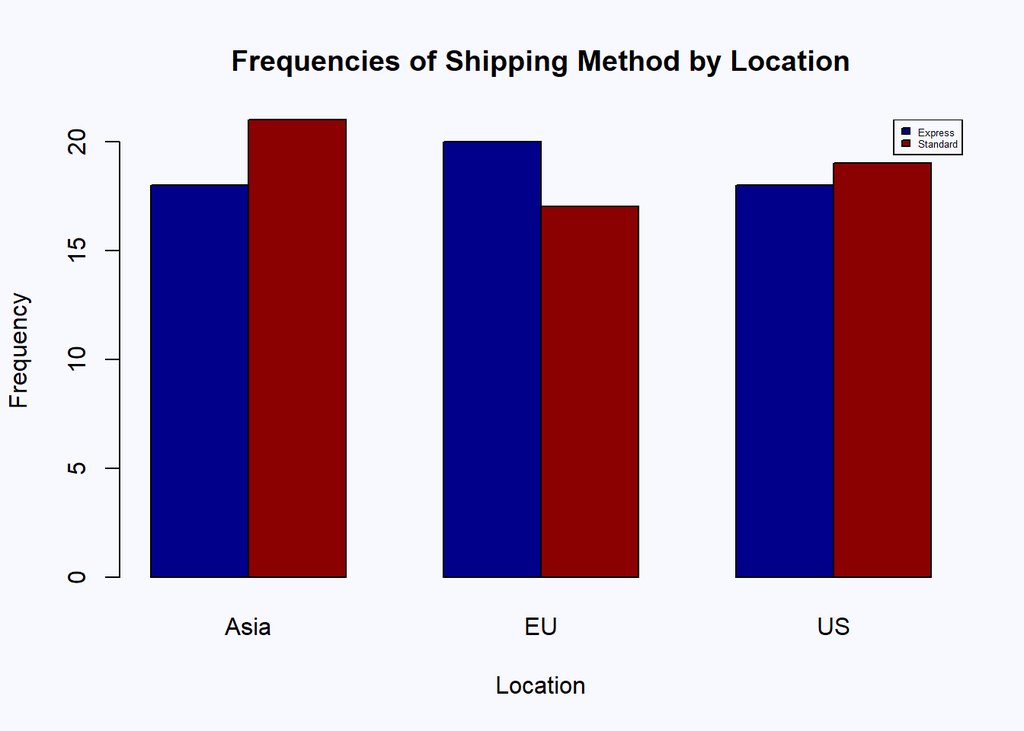

```r
par(bg = "#F8F8FF")
barplot(ship_loc,main = "Frequencies of Shipping Method by Location",
        xlab = "Location",ylab = "Frequency",beside = TRUE,
        col = c("blue4","red4"))
legend("topright", legend = c("Express", "Standard"),
       fill = c("blue4", "red4"), cex = 0.4)
```

According to the bar plot, the shipping method is close to each other in all three regions. While the standard method is more common in Asia and America, the express method is more common in Europe.  
**Question2**

How do satisfaction ratings vary across categories? Q2.1 - What are the prevalent customer rating options (bad, medium, goog) within specific categories? Q2.2 - Which seller rating options (bad, medium, good) are common within specific categories?

```r
par(mfrow=c(1,1))

c_rate = table(amazon1$Category,amazon1$Customerrating)
c_rate
```

```
##
##                  bad medium good
##   Beauty           0     12    9
##   Books            1     13    9
##   Clothing         1      9   13
##   Electronics      1     12    9
##   Home & Kitchen   0     10   14
```

customer rating for each category

```r
s_rate = table(amazon1$Category,amazon1$Sellerrating)
s_rate
```

```
##
##                  bad medium good
##   Beauty           7      8    6
##   Books           13      3    7
##   Clothing         5     14    4
##   Electronics      7      8    7
##   Home & Kitchen   7      7   10
```

```r
mypalet<-brewer.pal(5,"Set3")
par(bg = "#F8F8FF")
```

seller rating for each category  
**q-2.1**

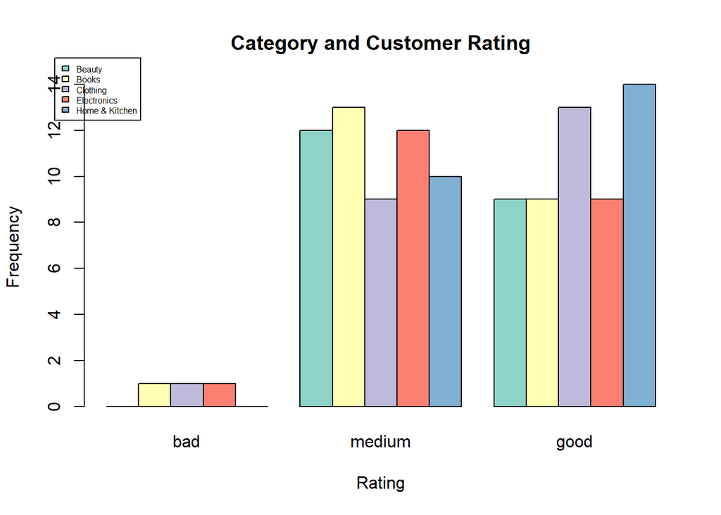

```r
barplot(c_rate,main="Category and Customer Rating",
        names.arg=c("bad", "medium", "good"),
        xlab="Rating", ylab="Frequency",col=mypalet, beside=TRUE,legend.text = c("Beauty","Books","Clothing","Electronics","Home & Kitchen"),args.legend = list(x = "topleft",inset = c(- 0.05, -0.08),cex=0.50))
```

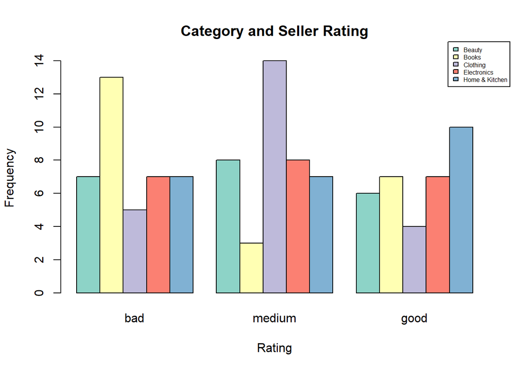

```r
barplot(s_rate,main="Category and Seller Rating",
        names.arg=c("bad", "medium", "good"),
        xlab="Rating", ylab="Frequency",col=mypalet, beside=TRUE,legend.text = c("Beauty","Books","Clothing","Electronics","Home & Kitchen"),args.legend = list(x = "topright",inset = c(- 0.05, -0.08),cex=0.50))
```

When we look at the bar plots, the rating as bad is relatively high compared to the previous customer rating. Likewise, medium and good ratings are also low compared to customer ratings. This shows that customers are satisfied, and sellers are less satisfied than customers.

**Question3**

How is the relationship between price and revenue,and there is any observable pattern discount and customer rating?

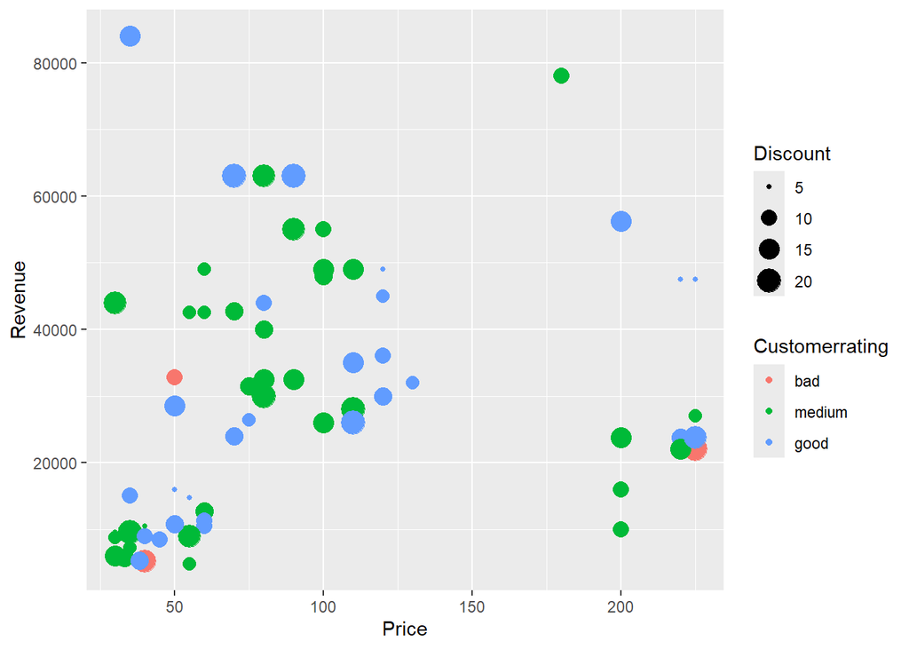

```r
ggplot(amazon1, aes(x = Price, y = Revenue,size=Discount,col=Customerrating)) +
  geom_point()
```

**Question4**

Is there a statistically significant correlation among Discount, Units sold, Revenue, and Advertising cost?

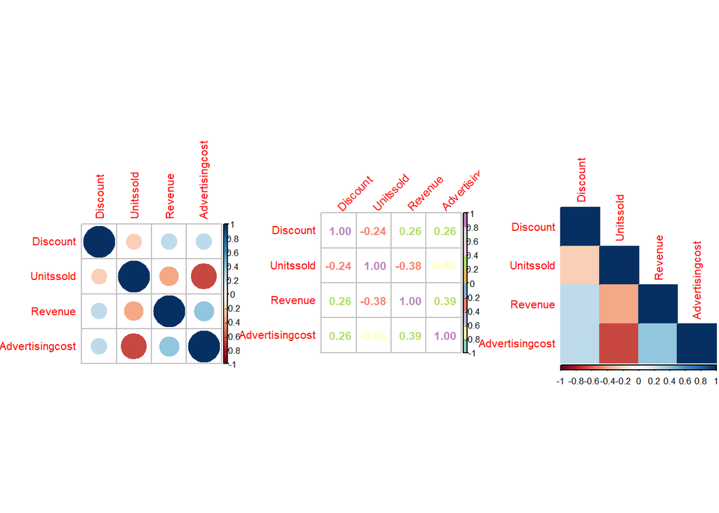

```r
par(mfrow=c(1,3))

corr = cor(amazon1[,c("Discount","Unitssold","Revenue","Advertisingcost")])

corrplot(corr)
corrplot(corr, method = 'number',col=brewer.pal(n=10, name="Set3"),tl.srt=45)
corrplot(corr, method = 'color', type="lower")
```

**Question5**

Does discount have any relationship with revenue? Does this change from quarter to year?

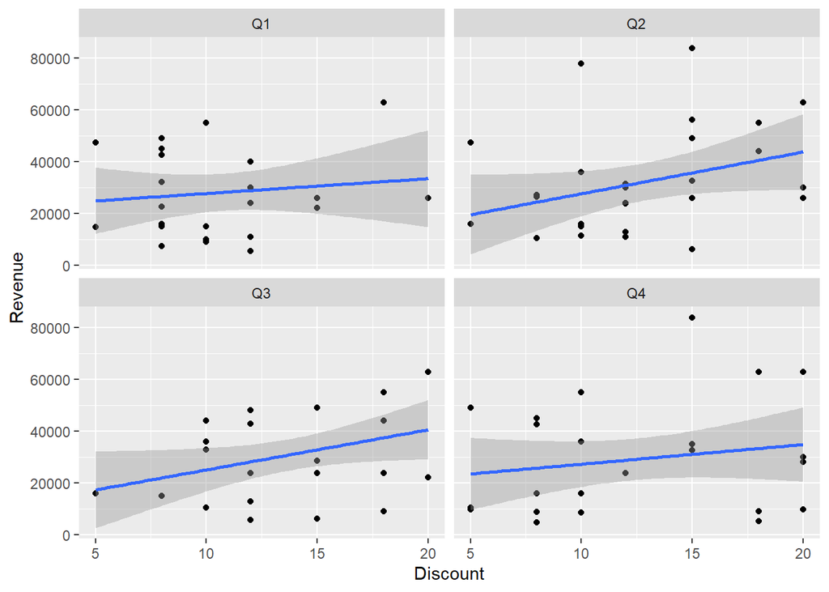

```r
par(mfrow=c(1,1))
ggplot(amazon1, aes(Discount, Revenue)) +
  geom_point() +
  geom_smooth(method="lm")+
  facet_wrap(~Quarter)
```

According to the pilots, there is a positive linear relationship every quarter. Additionally, there is a stronger positive linear relationship in the second quarter and the third quarter.

**Question6**

Is there a noticeable difference in Quarterly sales across locations?

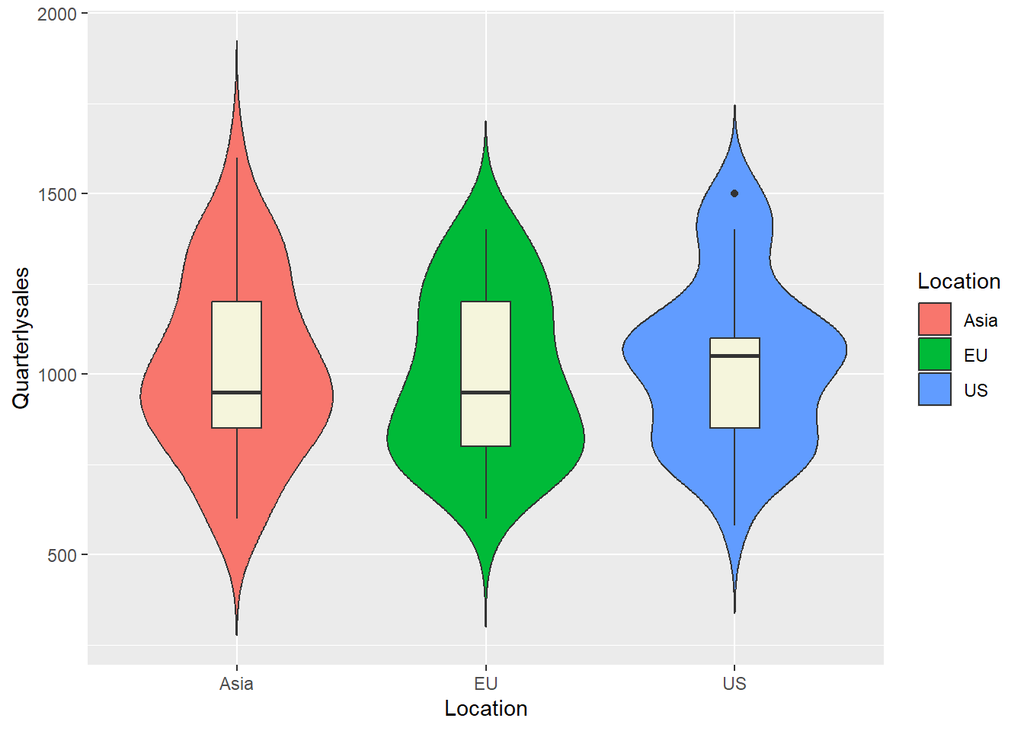

```r
ggplot(amazon1, aes(x=Location, y=Quarterlysales, fill=Location)) + geom_violin(trim=FALSE)  + geom_boxplot(width=0.2,fill="beige")
```

Compared to the violin plot, when we look at the plot in the Asian region, it is weak at both ends and swollen in the middle. This shows us that sales are concentrated around the median. Looking at Europe and America, we see that quarterly sales are concentrated around the median, although their ends are more potent than in Asia.

# CONCLUSION